# Practical Machine Learning Project

David

Friday, July 11, 2014

## Objective:

The goal of this project is to predict the way we exercises using the weight lifting exercises dataset provided by:

Velloso, E.; Bulling, A.; Gellersen, H.; Ugulino, W.; Fuks, H. Qualitative Activity Recognition of Weight Lifting Exercises. Proceedings of 4th International Conference in Cooperation with SIGCHI (Augmented Human ’13) . Stuttgart, Germany: ACM SIGCHI, 2013.

I will first clean up the data by removing the identifier columns and columns with majority missing values. Then I will use 10 fold cross validation method to evaluate the expected out of sample error. The predictive algorithm that I will use are:

1. C5.0 decision tree
2. Random Forest
3. Support Vector Machine

## Read in train and test data

The training and test data set is downloaded and saved in the project folder named *data*.

```r
#Some columns such as kurtosis_roll_belt are coded as character string
#do not treat string as factors
train=read.csv("./data/training.csv",stringsAsFactors=F)

test=read.csv("./data/testing.csv",stringsAsFactors=F)
```

## Explore training dataset and select features for incursion

I also created a general vector that stores the names of column to keep for the training,validation and test data set. The following columns are eliminated.

1. The first 7 identifier columns,they do not provide useful information for predicting our classe variable.
2. There are 100 columns with majority NA or empty string.

```r
#Examine the distribution of outcome variable
table(train$classe)
```

```
##
##    A    B    C    D    E
## 5580 3797 3422 3216 3607
```

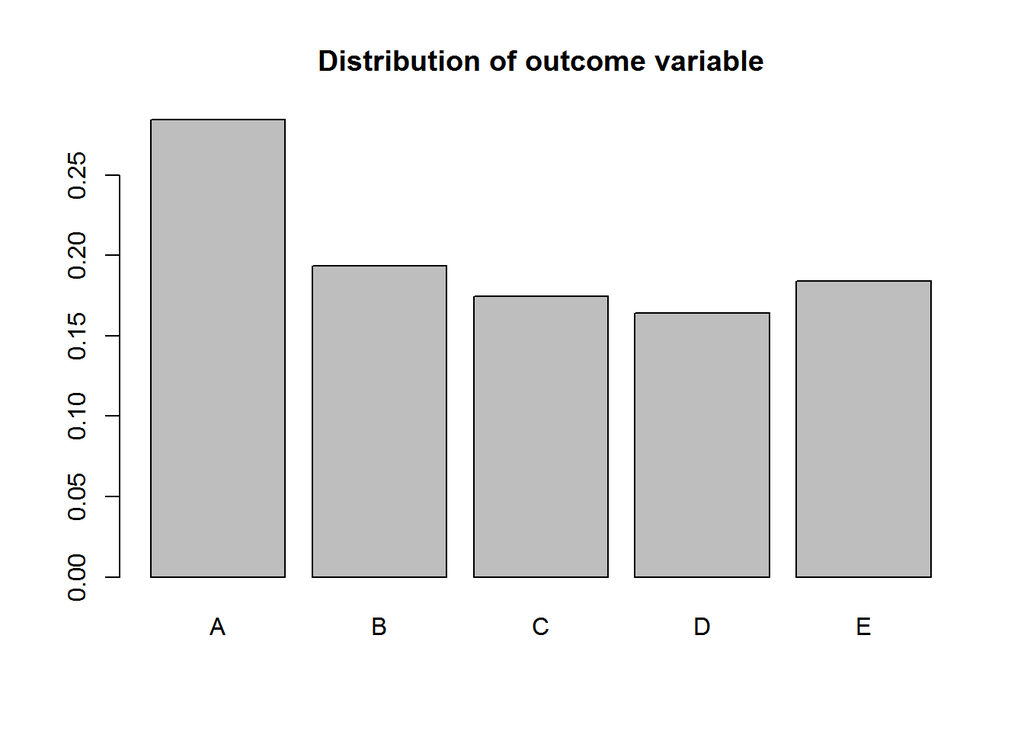

```r
barplot(prop.table(table(train$classe)),main="Distribution of outcome variable")
```

```r
#The distribution of the outcome variable is fairly uniform

numNA=apply(train,MARGIN = 2,function(x){sum(is.na(x)|x=="")})

colToKeep<-names(train)[!numNA]

#Get rid of the first 7 identifier columns
colToKeep<-colToKeep[-c(1:7)]

train=train[,colToKeep]
train$classe=factor(train$classe)
n=length(colToKeep)
test=test[,c(colToKeep[-n],"problem_id")]
```

## Cross Validation

```r
library(caret)
set.seed(13579)
folds<-createFolds(train$classe,k=10)
```

# Predictive Modeling

## C5.0 decision tree

```r
library(C50)
cv_results.c50<-sapply(folds,function(x){
  training<-train[x,]
  validation<-train[-x,]
  n=ncol(training)
  modFit.c50<-C5.0(training[,-n], training$classe,10)
  pred.c50<-predict(modFit.c50, validation[,-n])
  accuracy=sum(validation$classe==pred.c50)/nrow(validation)
  return(accuracy)
})

mean(cv_results.c50)
```

```
## [1] 0.9364
```

## Random Forest

```r
library("randomForest")
#Random Forests

cv_results.rf<-sapply(folds,function(x){
  training<-train[x,]
  validation<-train[-x,]
  n=ncol(training)
  modFit.rf<-randomForest(training[,-n], training$classe,ntree=50)
  pred.rf<-predict(modFit.rf,validation[,-n])
  accuracy=sum(validation$classe==pred.rf)/nrow(validation)
  return(accuracy)
})

mean(cv_results.rf)
```

```
## [1] 0.9438
```

## Support Vector Machine

```r
library("kernlab")

cv_results.svm<-sapply(folds,function(x){
  training<-train[x,]
  validation<-train[-x,]
  modFit.svm<-ksvm(classe~.,data=training,kernel="rbfdot")
  pred.svm<-predict(modFit.svm,validation)
  accuracy=sum(validation$classe==pred.svm)/nrow(validation)
  return(accuracy)
})
```

[output not shown]

```r
mean(cv_results.svm)
```

```
## [1] 0.8085
```

## Expected Out of Sample Error

Base on the result, random forest has the best performance with an average overall accuracy rate of 94%. I will now use random forest to train my final model using the entire training data set. The expected out of sample error is 6%.

```r
modFit<-randomForest(train[,-n], train$classe,ntree=50)
pred<-predict(modFit,test[,-n])
data.frame(test$problem_id,pred)
```

```
##    test.problem_id pred
## 1                1    B
## 2                2    A
## 3                3    B
## 4                4    A
## 5                5    A
## 6                6    E
## 7                7    D
## 8                8    B
## 9                9    A
## 10              10    A
## 11              11    B
## 12              12    C
## 13              13    B
## 14              14    A
## 15              15    E
## 16              16    E
## 17              17    A
## 18              18    B
## 19              19    B
## 20              20    B
```